# 人工智慧 進階課程 - Deep Learning- Capsule Networks Part- 04 - An introduction to Capsule Network - Python Tutorial

# MNIST 數據 資料庫 - 手寫 數字圖像

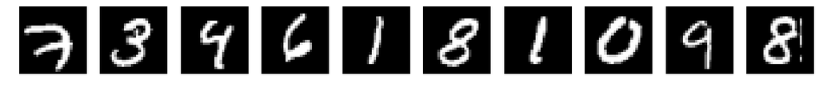

```python
n_samples = 10

plt.figure(figsize=(n_samples * 2, 3))
for index in range(n_samples):
    plt.subplot(1, n_samples, index + 1)
    sample_image = mnist.train.images[index].reshape(28, 28)
    plt.imshow(sample_image,cmap=plt.get_cmap('gray'))  # cmap="binary",
    plt.axis("off")

plt.show()
```

# 相應的標籤 Label

```python
mnist.train.labels[:n_samples]
```

```
array([7, 3, 4, 6, 1, 8, 1, 0, 9, 8], dtype=uint8)
```

[figure not shown]

- 建立一個 膠囊網絡 - CapsNets > 輸入的圖像 Input Images → 計算損失 Loss → 重新 構造損失 Reconstruction Loss > 標籤 Label → 掩蓋 Mask > 判別區分- 這些圖像 - 底層開始構建 - 計算圖 Graph - 由 下往上移 - 由 左向右移

```
                            Loss
                            損 失
                              ↑
                    ┌─────────┴─────────┐
          Labels  Margin Loss  Reconstruction Loss
          標 簽 → 邊 際 損 失     重 新 構 造 損 失

                    ↑                   ↑
                Length               Decoder
                  模 長              解 碼 器

                    ↑                   ↑
             Digit Capsules     Mask
             數 字 膠 囊 們  ───遮 蓋────┘

               ↖↑↗ ↖↑↗ ↖↑↗
            Primary Capsules
                主 膠 囊 們

                    ↑
               Input Images
              輸 入 的 圖 像
```

# 輸入圖像 Input Images

- 創建一個圖像 佔位符 - Placeholder
  - 輸入圖像
    - 28×28 像素 Pixels
    - 1 通道 Grayscale

```python
X = tf.placeholder(shape=[None, 28, 28, 1], dtype=tf.float32, name="X")
```

# Primary Capsules 主膠囊

- 第一層
  - 32個 capsules 膠囊
    - 特徵映射組成
  - 每個特徵映射為 6$\times$6個 膠囊
  - 每個膠囊輸出 8維 8D 的 激活向量 Activation Vector

[figure not shown]

```python
caps1_n_maps = 32
caps1_n_caps = caps1_n_maps * 6 * 6  # 1152 主膠囊 primary capsules
caps1_n_dims = 8
```

- 為了計算輸出 Outputs
  - 應用兩個常規的捲積層
  - Two Cnvolutional Layers

```python
conv1_params = {
    "filters": 256,
    "kernel_size": 9,
    "strides": 1,
    "padding": "valid",
    "activation": tf.nn.relu,
}

conv2_params = {
    "filters": caps1_n_maps * caps1_n_dims, # 256 個 卷積濾波器
    "kernel_size": 9,
    "strides": 2,
    "padding": "valid",
    "activation": tf.nn.relu
}
```

```python
conv1 = tf.layers.conv2d(X, name="conv1", **conv1_params)
conv2 = tf.layers.conv2d(conv1, name="conv2", **conv2_params)
```

[output not shown]

- 一個 - 9x9 核 kernel size
- 沒有使用填充 No Padding
  - padding": "valid"
  - 該圖像 - 每經歷一個卷積層
    - 就會縮減 $ 9-1=8 $ 個像素
  - 從$28\times 28$ 到$20 \times 20$，再從$20\times 20$ 到$12\times 12$
  - 由於在第二個卷積層中使用了大小 - 為 2的步幅 Stride of 2
  - 該圖像的大小就被除以2
- 最後會得到 $6\times 6$ 的 特徵映射 Feature Map
- 接著
  - 重塑該輸出以獲得一組8D向量
    - 用來表示主膠囊的輸出
  - `conv2`的輸出是一個數組
    - 包含對於每個實例
      - 都有 32×8=256 個 特徵映射 Feature Map
    - 其中每個特徵映射為6×6
  - 所以該輸出的形狀為 (*batch size*, 6, 6, 256)
- 我們 想要把 256 分到 32個 8維 向量中
  - 通過使用重塑 Reshape (*batch size*, 6, 6, 32, 8)
  - 然而
    - 由於首個膠囊層會被
      - Fully Connect 完全連接
      - 到 下一個膠囊層 Capsule Layer
    - 簡單地 把它 扁平 flatten 成 6×6 的網格 grids
  - 只需要把它重塑 Reshape (*batch size*, 6×6×32, 8)

```python
caps1_raw = tf.reshape(conv2, [-1, caps1_n_caps, caps1_n_dims],
                       name="caps1_raw")
```

- 現在需要壓縮 `squash()` 這些向量 Vectors
  - 定義`squash()`函數，基於論文中的公式（1）：$\operatorname{squash}(\mathbf{s}) = \dfrac{\|\mathbf{s}\|^2}{1 + \|\mathbf{s}\|^2} \dfrac{\mathbf{s}}{\|\mathbf{s}\|}$
- `squash()`函數
  - 會壓縮 squash 所有的向量 Vectors
    - 到 給定的數組中 Array
    - 沿給定軸 -默認情況 - 為最後一個軸

      ```
            - by default, the last axis
      ```

**當心**，這裡有一個 Bug $\|\mathbf{s}\|=0$時，$\|\mathbf{s}\|$ 為undefined

```
- 不能直接使用 tf.norm()
- 否則會在訓練過程中失敗
    - 如果一個向量為 0，那麼梯度就會是 `nan`
    - 當優化器更新變量時，這些變量也會變為  nan
    - 從那個時刻起，就止步在  nan 那裡
- 解決的方法是 - 手動 實現 norm
    - 計算的時候 加上一個很小的值 epsilon：
```

$\|\mathbf{s}\| \approx \sqrt{\sum\limits_i{{s_i}^2}\,\ ,+ \epsilon}$

```python
def squash(s, axis=-1, epsilon=1e-7, name=None):
    with tf.name_scope(name, default_name="squash"):
        squared_norm = tf.reduce_sum(tf.square(s), axis=axis,
                                     keep_dims=True)
        safe_norm = tf.sqrt(squared_norm + epsilon)
        squash_factor = squared_norm / (1. + squared_norm)
        unit_vector = s / safe_norm
        return squash_factor * unit_vector
```

- squash 函數
  - 獲得 每個主膠囊 Primary Capsules$\mathbf{u}_i$ 的輸出

caps1_output = squash(caps1_raw, name="caps1_output")

[figure not shown]